# Moneyball-dataset-capstone-project

## Moneyball

**Using R to find the replacement for the Lost Boys**

BACKGROUND (From Wikipedia) The 2002 Oakland A’s The Oakland Athletics’ 2002 season was the team’s 35th in Oakland, California. It was also the 102nd season in franchise history. The Athletics finished first in the American League West with a record of 103-59. The Athletics’ 2002 campaign ranks among the most famous in franchise history. Following the 2001 season, Oakland saw the departure of three key players (the lost boys). Billy Beane, the team’s general manager, responded with a series of under-the-radar free agent signings. The new-look Athletics, despite a comparative lack of star power, surprised the baseball world by besting the 2001 team’s regular season record. The team is most famous, however, for winning 20 consecutive games between August 13 and September 4, 2002.[1] The Athletics’ season was the subject of Michael Lewis’ 2003 book Moneyball: The Art of Winning an Unfair Game (as Lewis was given the opportunity to follow the team around throughout that season)

This project is based off the book written by Michael Lewis (later turned into a movie). Moneyball Book The central premise of book Moneyball is that the collective wisdom of baseball insiders (including players, managers, coaches, scouts, and the front office) over the past century is subjective and often flawed. Statistics such as stolen bases, runs batted in, and batting average, typically used to gauge players, are relics of a 19th-century view of the game and the statistics available at that time. The book argues that the Oakland A’s’ front office took advantage of more analytical gauges of player performance to field a team that could better compete against richer competitors in Major League Baseball (MLB). Rigorous statistical analysis had demonstrated that on-base percentage and slugging percentage are better indicators of offensive success, and the A’s became convinced that these qualities were cheaper to obtain on the open market than more historically valued qualities such as speed and contact. These observations often flew in the face of conventional baseball wisdom and the beliefs of many baseball scouts and executives.

By re-evaluating the strategies that produce wins on the field, the 2002 Athletics, with approximately US 44 million dollars in salary, were competitive with larger market teams such as the New York Yankees, who spent over US$125 million in payroll that same season.

Because of the team’s smaller revenues, Oakland is forced to find players undervalued by the market, and their system for finding value in undervalued players has proven itself thus far. This approach brought the A’s to the playoffs in 2002 and 2003. In this project we’ll work with some data and with the goal of trying to find replacement players for the ones lost at the start of the off-season - During the 2001-02 offseason, the team lost three key free agents to larger market teams: 2000 AL MVP Jason Giambi to the New York Yankees, outfielder Johnny Damon to the Boston Red Sox, and closer Jason Isringhausen to the St. Louis Cardinals.

I am using data from Sean Lahaman’s [Website](http://www.seanlahman.com/) a very useful source for baseball statistics.

Other resources - Apart from home runs(which I enjoyed hitting in my childhood on a video game.) I knew nothing about baseball so this [video](https://www.youtube.com/watch?v=0bKkGeROiPA) helped me.

**Loading up the dataframe with csv batting**

```r
batting <- read.csv('Batting.csv')
head(batting)
```

```
##    playerID yearID stint teamID lgID  G G_batting AB R H X2B X3B HR RBI SB
## 1 aardsda01   2004     1    SFN   NL 11        11  0 0 0   0   0  0   0  0
## 2 aardsda01   2006     1    CHN   NL 45        43  2 0 0   0   0  0   0  0
## 3 aardsda01   2007     1    CHA   AL 25         2  0 0 0   0   0  0   0  0
## 4 aardsda01   2008     1    BOS   AL 47         5  1 0 0   0   0  0   0  0
## 5 aardsda01   2009     1    SEA   AL 73         3  0 0 0   0   0  0   0  0
## 6 aardsda01   2010     1    SEA   AL 53         4  0 0 0   0   0  0   0  0
##   CS BB SO IBB HBP SH SF GIDP G_old
## 1  0  0  0   0   0  0  0    0    11
## 2  0  0  0   0   0  1  0    0    45
## 3  0  0  0   0   0  0  0    0     2
## 4  0  0  1   0   0  0  0    0     5
## 5  0  0  0   0   0  0  0    0    NA
## 6  0  0  0   0   0  0  0    0    NA
```

checking data structure of data frame

```r
str(batting)
```

```
## 'data.frame':    97889 obs. of  24 variables:
##  $ playerID : Factor w/ 18107 levels "aardsda01","aaronha01",..: 1 1 1 1 1 1 1 2 2 2 ...
##  $ yearID   : int  2004 2006 2007 2008 2009 2010 2012 1954 1955 1956 ...
##  $ stint    : int  1 1 1 1 1 1 1 1 1 1 ...
##  $ teamID   : Factor w/ 149 levels "ALT","ANA","ARI",..: 117 35 33 16 116 116 93 80 80 80 ...
##  $ lgID     : Factor w/ 6 levels "AA","AL","FL",..: 4 4 2 2 2 2 2 4 4 4 ...
##  $ G        : int  11 45 25 47 73 53 1 122 153 153 ...
##  $ G_batting: int  11 43 2 5 3 4 NA 122 153 153 ...
##  $ AB       : int  0 2 0 1 0 0 NA 468 602 609 ...
##  $ R        : int  0 0 0 0 0 0 NA 58 105 106 ...
##  $ H        : int  0 0 0 0 0 0 NA 131 189 200 ...
##  $ X2B      : int  0 0 0 0 0 0 NA 27 37 34 ...
##  $ X3B      : int  0 0 0 0 0 0 NA 6 9 14 ...
##  $ HR       : int  0 0 0 0 0 0 NA 13 27 26 ...
##  $ RBI      : int  0 0 0 0 0 0 NA 69 106 92 ...
##  $ SB       : int  0 0 0 0 0 0 NA 2 3 2 ...
##  $ CS       : int  0 0 0 0 0 0 NA 2 1 4 ...
##  $ BB       : int  0 0 0 0 0 0 NA 28 49 37 ...
##  $ SO       : int  0 0 0 1 0 0 NA 39 61 54 ...
##  $ IBB      : int  0 0 0 0 0 0 NA NA 5 6 ...
##  $ HBP      : int  0 0 0 0 0 0 NA 3 3 2 ...
##  $ SH       : int  0 1 0 0 0 0 NA 6 7 5 ...
##  $ SF       : int  0 0 0 0 0 0 NA 4 4 7 ...
##  $ GIDP     : int  0 0 0 0 0 0 NA 13 20 21 ...
##  $ G_old    : int  11 45 2 5 NA NA NA 122 153 153 ...
```

Checking at-bats values

```r
head(batting$AB)
```

```
## [1] 0 2 0 1 0 0
```

Checking 2’s scored

```r
head(batting$X2B)
```

```
## [1] 0 0 0 0 0 0
```

creating Batting average column BA = hits/at bats

```r
#creating Batting average column BA =  hits/at bats
batting$BA <- batting$H / batting$AB
tail(batting$BA)
```

```
## [1] 0.0000000 0.1230769 0.2746479 0.1470588 0.2745098 0.2138728
```

```r
#calculating ones by subtracting 2s,3s and home runs from total hits H i.e. 1B = H-2B-3B-HR
batting$X1B = batting$H - 2*batting$X2B -3*batting$X3B - batting$HR
tail(batting$X1B)
```

```
## [1]  0  6 72  5 75 22
```

```r
#creating 2 new columns On Base Percentage (OBP) and Slugging Percentage (SLG)
# OBP = (H+BB+HBP)/(AB+BB+HBP+SF)
# SLG = ((1*X1B)+(2*X2B)+(3*X3B)+(4*HR))/AB
#reference - wikipedia

batting$OBP = (batting$H+ batting$BB + batting$HBP)/ (batting$AB+batting$BB + batting$HBP + batting$SF)

batting$SLG = (1* batting$X1B + 2* batting$X2B + 3* batting$X3B + 4 * batting$HR)/batting$AB
tail(batting)
```

```
##        playerID yearID stint teamID lgID   G G_batting  AB  R   H X2B X3B
## 97884 zieglbr01   2013     1    ARI   NL  78        78   2  0   0   0   0
## 97885 zimmejo02   2013     1    WAS   NL  32        32  65  4   8   1   0
## 97886 zimmery01   2013     1    WAS   NL 147       147 568 84 156  26   2
## 97887  zitoba01   2013     1    SFN   NL  30        30  34  3   5   0   0
## 97888 zobribe01   2013     1    TBA   AL 157       157 612 77 168  36   3
## 97889 zuninmi01   2013     1    SEA   AL  52        52 173 22  37   5   0
##       HR RBI SB CS BB  SO IBB HBP SH SF GIDP G_old        BA X1B       OBP
## 97884  0   0  0  0  0   0   0   0  0  0    0    NA 0.0000000   0 0.0000000
## 97885  0   2  0  0  1  20   0   0  6  1    0    NA 0.1230769   6 0.1343284
## 97886 26  79  6  0 60 133   2   2  0  3   16    NA 0.2746479  72 0.3443918
## 97887  0   2  0  0  0   8   0   0  9  0    1    NA 0.1470588   5 0.1470588
## 97888 12  71 11  3 72  91   4   7  1  6   18    NA 0.2745098  75 0.3543759
## 97889  5  14  1  0 16  49   0   3  0  1    5    NA 0.2138728  22 0.2901554
##             SLG
## 97884 0.0000000
## 97885 0.1230769
## 97886 0.4119718
## 97887 0.1470588
## 97888 0.3333333
## 97889 0.3005780
```

```r
str(batting)
```

```
## 'data.frame':    97889 obs. of  28 variables:
##  $ playerID : Factor w/ 18107 levels "aardsda01","aaronha01",..: 1 1 1 1 1 1 1 2 2 2 ...
##  $ yearID   : int  2004 2006 2007 2008 2009 2010 2012 1954 1955 1956 ...
##  $ stint    : int  1 1 1 1 1 1 1 1 1 1 ...
##  $ teamID   : Factor w/ 149 levels "ALT","ANA","ARI",..: 117 35 33 16 116 116 93 80 80 80 ...
##  $ lgID     : Factor w/ 6 levels "AA","AL","FL",..: 4 4 2 2 2 2 2 4 4 4 ...
##  $ G        : int  11 45 25 47 73 53 1 122 153 153 ...
##  $ G_batting: int  11 43 2 5 3 4 NA 122 153 153 ...
##  $ AB       : int  0 2 0 1 0 0 NA 468 602 609 ...
##  $ R        : int  0 0 0 0 0 0 NA 58 105 106 ...
##  $ H        : int  0 0 0 0 0 0 NA 131 189 200 ...
##  $ X2B      : int  0 0 0 0 0 0 NA 27 37 34 ...
##  $ X3B      : int  0 0 0 0 0 0 NA 6 9 14 ...
##  $ HR       : int  0 0 0 0 0 0 NA 13 27 26 ...
##  $ RBI      : int  0 0 0 0 0 0 NA 69 106 92 ...
##  $ SB       : int  0 0 0 0 0 0 NA 2 3 2 ...
##  $ CS       : int  0 0 0 0 0 0 NA 2 1 4 ...
##  $ BB       : int  0 0 0 0 0 0 NA 28 49 37 ...
##  $ SO       : int  0 0 0 1 0 0 NA 39 61 54 ...
##  $ IBB      : int  0 0 0 0 0 0 NA NA 5 6 ...
##  $ HBP      : int  0 0 0 0 0 0 NA 3 3 2 ...
##  $ SH       : int  0 1 0 0 0 0 NA 6 7 5 ...
##  $ SF       : int  0 0 0 0 0 0 NA 4 4 7 ...
##  $ GIDP     : int  0 0 0 0 0 0 NA 13 20 21 ...
##  $ G_old    : int  11 45 2 5 NA NA NA 122 153 153 ...
##  $ BA       : num  NaN 0 NaN 0 NaN ...
##  $ X1B      : num  0 0 0 0 0 0 NA 46 61 64 ...
##  $ OBP      : num  NaN 0 NaN 0 NaN ...
##  $ SLG      : num  NaN 0 NaN 0 NaN ...
```

```r
#reading salary csv
sal <- read.csv('Salaries.csv')
head(sal)
```

```
##   yearID teamID lgID  playerID  salary
## 1   1985    BAL   AL murraed02 1472819
## 2   1985    BAL   AL  lynnfr01 1090000
## 3   1985    BAL   AL ripkeca01  800000
## 4   1985    BAL   AL  lacyle01  725000
## 5   1985    BAL   AL flanami01  641667
## 6   1985    BAL   AL boddimi01  625000
```

```r
summary(sal)
```

```
##      yearID         teamID      lgID            playerID
##  Min.   :1985   CLE    :  867   AL:11744   moyerja01:   25
##  1st Qu.:1993   LAN    :  861   NL:12212   vizquom01:   24
##  Median :1999   PHI    :  861              glavito02:   23
##  Mean   :1999   SLN    :  858              bondsba01:   22
##  3rd Qu.:2006   BAL    :  855              griffke02:   22
##  Max.   :2013   NYA    :  855              thomeji01:   22
##                 (Other):18799              (Other)  :23818
##      salary
##  Min.   :       0
##  1st Qu.:  250000
##  Median :  507950
##  Mean   : 1864357
##  3rd Qu.: 2100000
##  Max.   :33000000
##
```

```r
# have to remove some old data of year < 1985 as the data from salary starts from 1985 and we need to merge them
new_df <- subset(batting,batting$yearID>=1985)
summary(new_df)
```

```
##       playerID         yearID         stint          teamID
##  moyerja01:   27   Min.   :1985   Min.   :1.00   SDN    : 1313
##  mulhote01:   26   1st Qu.:1993   1st Qu.:1.00   CLE    : 1306
##  weathda01:   26   Median :2000   Median :1.00   PIT    : 1299
##  maddugr01:   25   Mean   :2000   Mean   :1.08   NYN    : 1297
##  sierrru01:   25   3rd Qu.:2007   3rd Qu.:1.00   BOS    : 1279
##  thomeji01:   25   Max.   :2013   Max.   :4.00   CIN    : 1279
##  (Other)  :35498                                 (Other):27879
##  lgID             G           G_batting            AB
##  AA:    0   Min.   :  1.0   Min.   :  0.00   Min.   :  0.0
##  AL:17226   1st Qu.: 14.0   1st Qu.:  4.00   1st Qu.:  3.0
##  FL:    0   Median : 34.0   Median : 27.00   Median : 47.0
##  NL:18426   Mean   : 51.7   Mean   : 46.28   Mean   :144.7
##  PL:    0   3rd Qu.: 77.0   3rd Qu.: 77.00   3rd Qu.:241.0
##  UA:    0   Max.   :163.0   Max.   :163.00   Max.   :716.0
##                             NA's   :1406     NA's   :4377
##        R                H               X2B              X3B
##  Min.   :  0.00   Min.   :  0.00   Min.   : 0.000   Min.   : 0.000
##  1st Qu.:  0.00   1st Qu.:  0.00   1st Qu.: 0.000   1st Qu.: 0.000
##  Median :  4.00   Median :  8.00   Median : 1.000   Median : 0.000
##  Mean   : 19.44   Mean   : 37.95   Mean   : 7.293   Mean   : 0.824
##  3rd Qu.: 30.00   3rd Qu.: 61.00   3rd Qu.:11.000   3rd Qu.: 1.000
##  Max.   :152.00   Max.   :262.00   Max.   :59.000   Max.   :23.000
##  NA's   :4377     NA's   :4377     NA's   :4377     NA's   :4377
##        HR              RBI               SB                CS
##  Min.   : 0.000   Min.   :  0.00   Min.   :  0.000   Min.   : 0.000
##  1st Qu.: 0.000   1st Qu.:  0.00   1st Qu.:  0.000   1st Qu.: 0.000
##  Median : 0.000   Median :  3.00   Median :  0.000   Median : 0.000
##  Mean   : 4.169   Mean   : 18.41   Mean   :  2.811   Mean   : 1.219
##  3rd Qu.: 5.000   3rd Qu.: 27.00   3rd Qu.:  2.000   3rd Qu.: 1.000
##  Max.   :73.000   Max.   :165.00   Max.   :110.000   Max.   :29.000
##  NA's   :4377     NA's   :4377     NA's   :4377      NA's   :4377
##        BB               SO              IBB               HBP
##  Min.   :  0.00   Min.   :  0.00   Min.   :  0.000   Min.   : 0.000
##  1st Qu.:  0.00   1st Qu.:  1.00   1st Qu.:  0.000   1st Qu.: 0.000
##  Median :  3.00   Median : 12.00   Median :  0.000   Median : 0.000
##  Mean   : 14.06   Mean   : 27.03   Mean   :  1.171   Mean   : 1.273
##  3rd Qu.: 21.00   3rd Qu.: 42.00   3rd Qu.:  1.000   3rd Qu.: 1.000
##  Max.   :232.00   Max.   :223.00   Max.   :120.000   Max.   :35.000
##  NA's   :4377     NA's   :4377     NA's   :4378      NA's   :4387
##        SH               SF              GIDP           G_old
##  Min.   : 0.000   Min.   : 0.000   Min.   : 0.00   Min.   :  0.0
##  1st Qu.: 0.000   1st Qu.: 0.000   1st Qu.: 0.00   1st Qu.: 11.0
##  Median : 0.000   Median : 0.000   Median : 1.00   Median : 32.0
##  Mean   : 1.465   Mean   : 1.212   Mean   : 3.25   Mean   : 49.7
##  3rd Qu.: 2.000   3rd Qu.: 2.000   3rd Qu.: 5.00   3rd Qu.: 77.0
##  Max.   :39.000   Max.   :17.000   Max.   :35.00   Max.   :163.0
##  NA's   :4377     NA's   :4378     NA's   :4377    NA's   :5189
##        BA             X1B              OBP             SLG
##  Min.   :0.000   Min.   : -8.00   Min.   :0.000   Min.   :0.000
##  1st Qu.:0.136   1st Qu.:  0.00   1st Qu.:0.188   1st Qu.:0.143
##  Median :0.233   Median :  4.00   Median :0.296   Median :0.280
##  Mean   :0.205   Mean   : 16.72   Mean   :0.262   Mean   :0.259
##  3rd Qu.:0.274   3rd Qu.: 26.50   3rd Qu.:0.342   3rd Qu.:0.357
##  Max.   :1.000   Max.   :191.00   Max.   :1.000   Max.   :4.000
##  NA's   :8905    NA's   :4377     NA's   :8821    NA's   :8905
```

merging both data frames on the basis of playerID and yearID

```r
combo <- merge(new_df,sal,c('playerID','yearID'))
head(combo)
```

```
##    playerID yearID stint teamID.x lgID.x  G G_batting AB  R  H X2B X3B HR
## 1 aardsda01   2004     1      SFN     NL 11        11  0  0  0   0   0  0
## 2 aardsda01   2007     1      CHA     AL 25         2  0  0  0   0   0  0
## 3 aardsda01   2008     1      BOS     AL 47         5  1  0  0   0   0  0
## 4 aardsda01   2009     1      SEA     AL 73         3  0  0  0   0   0  0
## 5 aardsda01   2010     1      SEA     AL 53         4  0  0  0   0   0  0
## 6 aardsda01   2012     1      NYA     AL  1        NA NA NA NA  NA  NA NA
##   RBI SB CS BB SO IBB HBP SH SF GIDP G_old  BA X1B OBP SLG teamID.y lgID.y
## 1   0  0  0  0  0   0   0  0  0    0    11 NaN   0 NaN NaN      SFN     NL
## 2   0  0  0  0  0   0   0  0  0    0     2 NaN   0 NaN NaN      CHA     AL
## 3   0  0  0  0  1   0   0  0  0    0     5   0   0   0   0      BOS     AL
## 4   0  0  0  0  0   0   0  0  0    0    NA NaN   0 NaN NaN      SEA     AL
## 5   0  0  0  0  0   0   0  0  0    0    NA NaN   0 NaN NaN      SEA     AL
## 6  NA NA NA NA NA  NA  NA NA NA   NA    NA  NA  NA  NA  NA      NYA     AL
##    salary
## 1  300000
## 2  387500
## 3  403250
## 4  419000
## 5 2750000
## 6  500000
```

```r
summary(combo)
```

```
##       playerID         yearID         stint          teamID.x
##  moyerja01:   27   Min.   :1985   Min.   :1.000   LAN    :  940
##  thomeji01:   25   1st Qu.:1993   1st Qu.:1.000   PHI    :  937
##  weathda01:   25   Median :1999   Median :1.000   BOS    :  935
##  vizquom01:   24   Mean   :1999   Mean   :1.098   NYA    :  928
##  gaettga01:   23   3rd Qu.:2006   3rd Qu.:1.000   CLE    :  920
##  griffke02:   23   Max.   :2013   Max.   :4.000   SDN    :  914
##  (Other)  :25250                                  (Other):19823
##  lgID.x           G            G_batting            AB
##  AA:    0   Min.   :  1.00   Min.   :  0.00   Min.   :  0.0
##  AL:12292   1st Qu.: 26.00   1st Qu.:  8.00   1st Qu.:  5.0
##  FL:    0   Median : 50.00   Median : 42.00   Median : 85.0
##  NL:13105   Mean   : 64.06   Mean   : 57.58   Mean   :182.4
##  PL:    0   3rd Qu.:101.00   3rd Qu.:101.00   3rd Qu.:336.0
##  UA:    0   Max.   :163.00   Max.   :163.00   Max.   :716.0
##                              NA's   :906      NA's   :2661
##        R                H               X2B              X3B
##  Min.   :  0.00   Min.   :  0.00   Min.   : 0.000   Min.   : 0.000
##  1st Qu.:  0.00   1st Qu.:  1.00   1st Qu.: 0.000   1st Qu.: 0.000
##  Median :  9.00   Median : 19.00   Median : 3.000   Median : 0.000
##  Mean   : 24.71   Mean   : 48.18   Mean   : 9.276   Mean   : 1.033
##  3rd Qu.: 43.00   3rd Qu.: 87.25   3rd Qu.:16.000   3rd Qu.: 1.000
##  Max.   :152.00   Max.   :262.00   Max.   :59.000   Max.   :23.000
##  NA's   :2661     NA's   :2661     NA's   :2661     NA's   :2661
##        HR              RBI               SB                CS
##  Min.   : 0.000   Min.   :  0.00   Min.   :  0.000   Min.   : 0.00
##  1st Qu.: 0.000   1st Qu.:  0.00   1st Qu.:  0.000   1st Qu.: 0.00
##  Median : 1.000   Median :  8.00   Median :  0.000   Median : 0.00
##  Mean   : 5.369   Mean   : 23.56   Mean   :  3.568   Mean   : 1.54
##  3rd Qu.: 7.000   3rd Qu.: 39.00   3rd Qu.:  3.000   3rd Qu.: 2.00
##  Max.   :73.000   Max.   :165.00   Max.   :110.000   Max.   :29.00
##  NA's   :2661     NA's   :2661     NA's   :2661      NA's   :2661
##        BB               SO              IBB               HBP
##  Min.   :  0.00   Min.   :  0.00   Min.   :  0.000   Min.   : 0.000
##  1st Qu.:  0.00   1st Qu.:  2.00   1st Qu.:  0.000   1st Qu.: 0.000
##  Median :  6.00   Median : 20.00   Median :  0.000   Median : 0.000
##  Mean   : 17.98   Mean   : 33.52   Mean   :  1.533   Mean   : 1.614
##  3rd Qu.: 29.00   3rd Qu.: 55.00   3rd Qu.:  2.000   3rd Qu.: 2.000
##  Max.   :232.00   Max.   :223.00   Max.   :120.000   Max.   :35.000
##  NA's   :2661     NA's   :2661     NA's   :2662      NA's   :2670
```

[output cut: 9 more lines]

```
##  Min.   :0.000   Min.   : -6.00   Min.   :0.000   Min.   :0.000
##  1st Qu.:0.160   1st Qu.:  0.00   1st Qu.:0.208   1st Qu.:0.173
##  Median :0.242   Median :  9.00   Median :0.305   Median :0.296
##  Mean   :0.212   Mean   : 21.16   Mean   :0.270   Mean   :0.270
##  3rd Qu.:0.276   3rd Qu.: 37.00   3rd Qu.:0.346   3rd Qu.:0.364
##  Max.   :1.000   Max.   :191.00   Max.   :1.000   Max.   :4.000
##  NA's   :5618    NA's   :2661     NA's   :5562    NA's   :5618
##     teamID.y     lgID.y         salary
##  CLE    :  935   AL:12304   Min.   :       0
##  PIT    :  932   NL:13093   1st Qu.:  255000
##  PHI    :  931              Median :  550000
##  SDN    :  923              Mean   : 1879256
##  LAN    :  921              3rd Qu.: 2150000
##  CIN    :  912              Max.   :33000000
##  (Other):19843
```

Get all details about lost boys

```r
lost_players <- subset(combo, combo$playerID %in% c('giambja01','damonjo01','saenzol01'))
head(lost_players,30)
```

```
##       playerID yearID stint teamID.x lgID.x   G G_batting  AB   R   H X2B
## 5135 damonjo01   1995     1      KCA     AL  47        47 188  32  53  11
## 5136 damonjo01   1996     1      KCA     AL 145       145 517  61 140  22
## 5137 damonjo01   1997     1      KCA     AL 146       146 472  70 130  12
## 5138 damonjo01   1998     1      KCA     AL 161       161 642 104 178  30
## 5139 damonjo01   1999     1      KCA     AL 145       145 583 101 179  39
## 5140 damonjo01   2000     1      KCA     AL 159       159 655 136 214  42
## 5141 damonjo01   2001     1      OAK     AL 155       155 644 108 165  34
## 5142 damonjo01   2002     1      BOS     AL 154       154 623 118 178  34
## 5143 damonjo01   2003     1      BOS     AL 145       145 608 103 166  32
## 5144 damonjo01   2004     1      BOS     AL 150       150 621 123 189  35
## 5145 damonjo01   2005     1      BOS     AL 148       148 624 117 197  35
## 5146 damonjo01   2006     1      NYA     AL 149       149 593 115 169  35
## 5147 damonjo01   2007     1      NYA     AL 141       141 533  93 144  27
## 5148 damonjo01   2008     1      NYA     AL 143       143 555  95 168  27
```

[output cut: 78 more lines]

CHecking stats of lost boys on 2001(the year they left)

```r
lost_year <-  subset(lost_players, lost_players$yearID == 2001)
lost_year
```

```
##        playerID yearID stint teamID.x lgID.x   G G_batting  AB   R   H X2B
## 5141  damonjo01   2001     1      OAK     AL 155       155 644 108 165  34
## 7878  giambja01   2001     1      OAK     AL 154       154 520 109 178  47
## 20114 saenzol01   2001     1      OAK     AL 106       106 305  33  67  21
##       X3B HR RBI SB CS  BB SO IBB HBP SH SF GIDP G_old        BA X1B
## 5141    4  9  49 27 12  61 70   1   5  5  4    7   155 0.2562112  76
## 7878    2 38 120  2  0 129 83  24  13  0  9   17   154 0.3423077  40
## 20114   1  9  32  0  1  19 64   1  13  1  3    9   106 0.2196721  13
##             OBP       SLG teamID.y lgID.y  salary
## 5141  0.3235294 0.2981366      OAK     AL 7100000
## 7878  0.4769001 0.5615385      OAK     AL 4103333
## 20114 0.2911765 0.3081967      OAK     AL  290000
```

Picking up their required game stats for the year

```r
reduced_df <- lost_year[,c('playerID','H','X2B','X3B','HR','OBP','SLG','BA','AB')]
reduced_df
```

```
##        playerID   H X2B X3B HR       OBP       SLG        BA  AB
## 5141  damonjo01 165  34   4  9 0.3235294 0.2981366 0.2562112 644
## 7878  giambja01 178  47   2 38 0.4769001 0.5615385 0.3423077 520
## 20114 saenzol01  67  21   1  9 0.2911765 0.3081967 0.2196721 305
```

Now coming back to our final task - Find Replacement Players for the key three players we lost! However, Lets say we have three constraints: -The total combined salary of the three players can not exceed 15 million dollars. -Their combined number of At Bats (AB) needs to be equal to or greater than the lost players. -Their mean OBP had to equal to or greater than the mean OBP of the lost player

Since the boys left in 2001,So we grab the list of players from combo with the YearID being 2001.

```r
library(dplyr)
avail.players <- filter(combo,yearID==2001)
head(avail.players)
```

```
##    playerID yearID stint teamID.x lgID.x   G G_batting  AB   R   H X2B X3B
## 1 abbotje01   2001     1      FLO     NL  28        28  42   5  11   3   0
## 2 abbotku01   2001     1      ATL     NL   6         6   9   0   2   0   0
## 3 abbotpa01   2001     1      SEA     AL  28         2   4   0   1   0   0
## 4 abreubo01   2001     1      PHI     NL 162       162 588 118 170  48   4
## 5 adamste01   2001     1      LAN     NL  43        41  39   2   2   1   0
## 6 agbaybe01   2001     1      NYN     NL  91        91 296  28  82  14   2
##   HR RBI SB CS  BB  SO IBB HBP SH SF GIDP G_old         BA X1B       OBP
## 1  0   5  0  0   3   7   0   1  0  0    1    28 0.26190476   5 0.3260870
## 2  0   0  1  0   0   3   0   0  0  0    0     6 0.22222222   2 0.2222222
## 3  0   0  0  0   0   1   0   0  1  0    0     2 0.25000000   1 0.2500000
## 4 31 110 36 14 106 137  11   1  0  9   13   162 0.28911565  31 0.3934659
## 5  0   1  0  0   3  19   0   0  5  1    0    41 0.05128205   0 0.1162791
## 6  6  27  4  5  36  73   0   5  1  1   11    91 0.27702703  42 0.3639053
##          SLG teamID.y lgID.y  salary
## 1 0.26190476      FLO     NL  300000
## 2 0.22222222      ATL     NL  600000
## 3 0.25000000      SEA     AL 1700000
## 4 0.44727891      PHI     NL 4983000
## 5 0.05128205      LAN     NL 2600000
## 6 0.33783784      NYN     NL  260000
```

Then I made a quick plot to see where I should cut-off for salary in respect to OBP

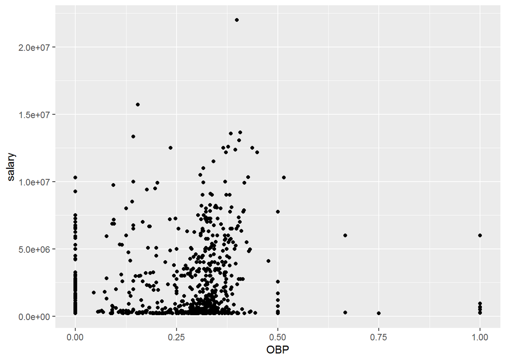

```r
library(ggplot2)
ggplot(avail.players,aes(x=OBP,y=salary)) + geom_point()
```

Looks like there is no point in paying above 8 million or so (I’m just assuming this number). I’ll choose that as a cut-off point. There are also a lot of players with OBP==0. Let’s remove them.

```r
avail.players <- filter(avail.players,salary<8000000,OBP>0)
print(sum(lost_players$AB))
```

```
## [1] 18274
```

```r
avail.players <- filter(avail.players,AB >= 500)
```

Let’s sort by OBP and see what we’ve got!

```r
possible <- head(arrange(avail.players,desc(OBP)),10)
```

Grab columns the managers are more interested in:

```r
possible <- possible[,c('playerID','OBP','AB','salary')]
possible
```

```
##     playerID       OBP  AB  salary
## 1  giambja01 0.4769001 520 4103333
## 2  heltoto01 0.4316547 587 4950000
## 3  berkmla01 0.4302326 577  305000
## 4  gonzalu01 0.4285714 609 4833333
## 5  thomeji01 0.4161491 526 7875000
## 6  alomaro01 0.4146707 575 7750000
## 7  edmonji01 0.4102142 500 6333333
## 8  gilesbr02 0.4035608 576 7333333
## 9  pujolal01 0.4029630 590  200000
## 10 olerujo01 0.4011799 572 6700000
```

Can’t choose giambja again, but the other ones look good (2-4). We will choose them!

```r
possible[2:4,]
```

```
##    playerID       OBP  AB  salary
## 2 heltoto01 0.4316547 587 4950000
## 3 berkmla01 0.4302326 577  305000
## 4 gonzalu01 0.4285714 609 4833333
```

looks like I just saved the 2001 Oakland A’s a lot of money!

**I am still working on and getting to know baseball more to understand this data for plotting other assumptions.**